# Análise e Transformação de Dados @ DEI-FCTUC

## Uma resolução dos exercícios da Ficha Prática nº 3 - Parte B usando MATLAB

### Autoria: Alberto Cardoso ©DEI2021/2022

Objetivo: Pretende-se continuar a análise de séries temporais, efetuando a identificação e a estimação do modelo a considerar (AR, ARMA e ARIMA), bem como realizar o teste de diagnóstico do modelo e a sua utilização para previsão de valores futuros da série.

**Exercício 3.**

Tendo por base a decomposição da série temporal nas suas componentes: tendência, sazonal, cíclica e errática/irregular, as fases seguintes correspondem à determinação do modelo mais adequado para representar o comportamento da série e possibilitar a previsão de valores futuros. Neste trabalho considera-se que a série temporal pode ser descrita por um processo univariado Auto-Regressivo (AR), Auto-Regressivo de Médias Móveis (ARMA) ou Auto-Regressivo Integrado de Médias Móveis (ARIMA). A escolha do modelo poderá ser estruturada nas seguintes 5 fases:

- Fase 1. Verificação da estacionaridade da série: Verificar se a série é estacionária e, caso não o seja, proceder a sucessivas diferenciações até atingir a estacionaridade.
- Fase 2. Identificação do Modelo: Determinar os critérios de definição do comportamento da série. Procura-se averiguar se é possível identificar a ordem do modelo usando os métodos de Função de Autocorrelação (FAC) e da Função de Autocorrelação Parcial (FACP).
- Fase 3. Estimação do Modelo: Estimar os modelos candidatos a serem selecionados após a identificação, procedendo-se à análise dos modelos mais adequados com base em critérios de escolha. Um dos critérios poderá ser o critério da soma do Erro Quadrático.
- Fase 4. Teste de Diagnóstico: Consiste em verificar se o modelo descreve adequadamente a série de dados objeto da análise.
- Fase 5. Previsão: Consiste em fazer a previsão, isto é, prever os valores futuros da série.

As seguintes tarefas devem ser aplicadas à série temporal considerada na Parte A desta ficha.

**Exercício 3.1** Verificar a estacionaridade da série regularizada e da série sem a tendência de ordem 1, usando a função **adftest** do Matlab (*Econometrics Toolbox*). Se o resultado desta função for o valor 1, a série deverá ser considerada estacionária..

```matlab
%--- Ler ficheiro com a série temporal regularizada (x1ro) e a série sem a tendência de grau 1 (x1ro_t1)
%--- e a tendência de grau 1 (tr1_1) que resultaram da parte A desta ficha prática
load lisbon_ro_t1.mat
```

```matlab
%plot inline -w 1200
%--- Ex. 3.1
if adftest(x1ro)==0 % teste de estacionaridade da série regularizada
    disp('Série não estacionária')
else
    disp('Série estacionária')
end

if adftest(x1ro_t1)==0 % teste de estacionaridade da série sem a tend. lin.
    disp('Série sem a tendência de 1a ordem não estacionária')
else
    disp('Série sem a tendência de 1a ordem estacionária')
end
```

```
Série não estacionária
Série sem a tendência de 1a ordem estacionária
```

**Exercício 3.2** Particionar a série estacionária (sem tendência de grau 1) em duas subséries: a série de treino que deve considerar as temperaturas entre 1980 e 2000 e deve ser usada para determinar os parâmetros dos modelos **AR**, **ARMA** e **ARIMA**; a série de teste que deve ser usada para posteriormente testar o desempenho dos modelos identificados para prever valores futuros entre 2001 e 2018. (**Nota**: as funções Matlab **ar**, **armax** e **arima** (*System Identification Toolbox*) necessitam que se crie um objeto **iddata(y,[ ],Ts,'TimeUnit','months')** para determinar os parâmetros dos modelos.)

```matlab
%--- Ex 3.2
iDez00=(2000-1980+1)*12; %Identificar índice para Dez 2000
serie_treino=x1ro_t1(1:iDez00); %Temp entre Jan 1980 e Dez 2000
serie_teste=x1ro_t1(iDez00+1:end); %Temp entre Jan 2001 e Dez 2018

%Identificar tendências para comparação entre a série original e a previsão
trend_treino=tr1_1(1:iDez00);
trend_teste=tr1_1(iDez00+1:end);

%Criar objeto IDDATA com os dados de treino
id_treino = iddata(serie_treino, [], 1, 'TimeUnit', 'Months');
```

**Exercício 3.3** Identificar o modelo **AR** para a série sem a tendência de ordem 1, considerando o resultado da Função de Autocorrelação Parcial (FACP) para definir o valor de *na* (ordem do modelo que se quer estimar) e definindo uma abordagem adequada (por exemplo, o método dos mínimos quadrados). Para isso, usar a função **ar** para obter o modelo e aceder aos coeficientes *a<sub>n</sub>*.

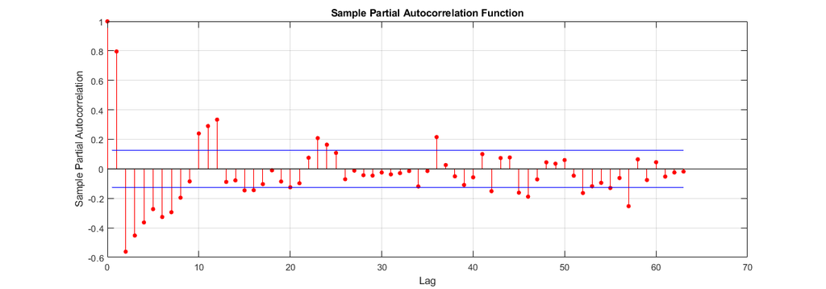

```matlab
%--- Ex 3.3
%====================MODELO AR=============================
figure;     % representação da FACP
            % FACP - indicador para a ordem de na (modelo AR)
parcorr(serie_treino,round(numel(serie_treino)/4));

opt1_AR = arOptions('Approach', 'ls'); % opções do modelo AR
na1_AR = 24; % histórico da variável a consierar (na)
model1_AR = ar(id_treino,na1_AR, opt1_AR);  % modelo AR
pcoef1_AR = polydata(model1_AR);  % parâmetros do modelo AR
```

**Exercício 3.4** Fazer a previsão de valores futuros da temperatura entre **2001 e 2018** usando os parâmetros (coeficientes) do modelo e usando também a função **forecast**. Validar o modelo comparando graficamente a previsão com a série temporal regularizada. Se necessário, repetir as tarefas 3.3 até obter o modelo adequado para a série. Considerar como métrica, por exemplo, a soma do quadrado do erro entre os valores medidos e estimados da série.

```
E1_AR =

  489.3719
```

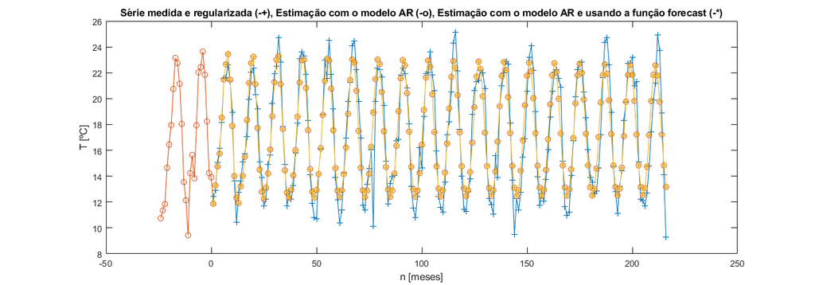

```matlab
%--- Ex 3.4
%Simulação do Modelo AR
y1_AR=serie_treino(end-na1_AR:end);
for k=(1:numel(serie_teste))+numel(y1_AR)
    y1_AR(k)=sum(-pcoef1_AR(2:end)'.*flip(y1_AR(k-na1_AR:k-1)));
end

%Adicionar as tendências para comparar com a série original
y1_AR=y1_AR+[trend_treino(end-na1_AR:end);trend_teste];

% Simulação do Modelo AR com forecast
y1_ARf=forecast(model1_AR,serie_treino(end-na1_AR:end),numel(serie_teste));

%Determinação dos vetores tempo para a série original e para a previsão
tp=-na1_AR:numel(y1_AR)-(na1_AR+1); %Tempo para a previsão
to=[1:numel(serie_teste)]; %Tempo para a série original (teste)

figure  % Compara a série com a sua estimação
plot(to,serie_teste+trend_teste,'-+',tp,y1_AR,'-o',to,y1_ARf+trend_teste,'-*');
xlabel('n [meses]');
ylabel('T [ºC]')
title('Série medida e regularizada (-+), Estimação com o modelo AR (-o), Estimação com o modelo AR e usando a função forecast (-*)')

% Métrica para análise (Soma dos quadrados do Erro)
E1_AR=sum(((serie_teste+trend_teste)-(y1_ARf+trend_teste)).^2)
```

**Exercício 3.5** Identificar o modelo **ARMA** para a série sem a tendência de ordem 1, considerando valores adequados para *na* (ordem do modelo que se quer estimar) e para *nc* (histórico do ruído branco a considerar). Verificar a utilidade da Função de Autocorrelação (FAC). Deve ser utilizada a função **armax** que permite definir um método de procura adequado (por exemplo, a opção automática definida por omissão).

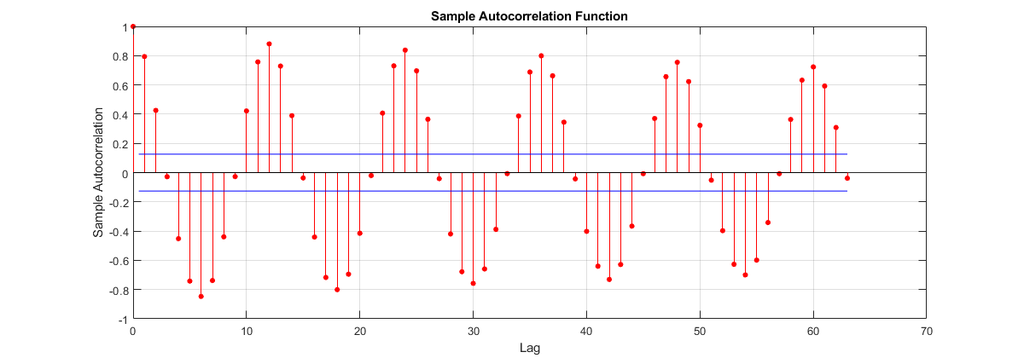

```matlab
%--- Ex. 3.5
% ======================Modelo ARMA=======================

figure;     % representação da FAC
            % FAC - possível indicador para a ordem de nc (modelo MA)
autocorr(serie_treino,round(numel(serie_treino)/4))
            % Opções para cálculo dos parâmetros
opt1_ARMAX = armaxOptions('SearchMethod', 'auto');
na1_ARMA=24;
nc1_ARMA=5;
            % Estimar parâmetros
model1_ARMA = armax(id_treino,[na1_ARMA nc1_ARMA],opt1_ARMAX);

            %Obter os coeficientes an e bn
[pa1_ARMA,pb1_ARMA,pc1_ARMA]=polydata(model1_ARMA);
```

**Exercício 3.6** Fazer a previsão de valores futuros da temperatura entre **2001 e 2018** usando os parâmetros do modelo e usando também a função **forecast**. Validar o modelo comparando graficamente a previsão com a série temporal regularizada. Se necessário, repetir as tarefas 3.5 até obter o modelo adequado para a série. Considerar como métrica, por exemplo, a soma do quadrado do erro entre os valores medidos e estimados da série.

```
E1_ARMA =

  474.8674
```

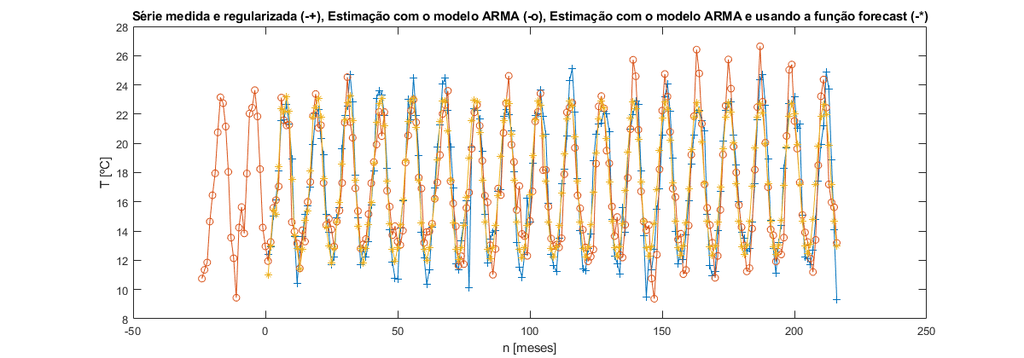

```matlab
%--- Ex. 3.6

npoints2pred=numel(serie_teste)+na1_ARMA+1;

            % histórico da série
y1_ARMA=serie_treino(end-na1_ARMA:end);
            % obtenção da série ruído branco
e = randn(numel(serie_teste)+numel(y1_ARMA),1);

% Simulação do Modelo ARMA
for k=numel(y1_ARMA):npoints2pred
    y1_ARMA(k)=sum(-pa1_ARMA(2:end)'.*flip(y1_ARMA(k-na1_ARMA:k-1)))+...
    sum(pc1_ARMA'.*flip(e(k-nc1_ARMA:k)));
end

%Adicionar as tendências para comparar com a série original
y1_ARMA=y1_ARMA+[trend_treino(end-na1_ARMA:end);trend_teste];

% Simulação do Modelo ARMA com forecast
y1_ARMAf=forecast(model1_ARMA,...
    serie_treino(end-na1_ARMA:end),numel(serie_teste));
tp=-na1_ARMA:numel(y1_ARMA)-(na1_ARMA+1);%Vetor tempo para a previsão

figure  % Compara a série com a sua estimação
plot(to,serie_teste+trend_teste,'-+',tp,y1_ARMA,'-o',...
    to,y1_ARMAf+trend_teste,'-*');
ylabel('T [ºC]')
xlabel('n [meses]');
title('Série medida e regularizada (-+), Estimação com o modelo ARMA (-o), Estimação com o modelo ARMA e usando a função forecast (-*)')

% Métrica para análise
E1_ARMA=sum(((serie_teste+trend_teste)-(y1_ARMAf+trend_teste)).^2)
```

**Exercício 3.7** Em alternativa às abordagens anteriores, identificar o modelo **ARIMA** da série regularizada (eventualmente, não estacionária), considerando valores adequados para *p* (grau do histórico da variável a considerar), *D* (número de operações de diferenciação até obter a série estacionária) e para *q* (grau do histórico do ruído branco a considerar). Para isso, usar a função **arima** para criar a estrutura do modelo e a função **estimate** para estimar os parâmetros do modelo da série.

```matlab
%-- Ex 3.7
if adftest(diff(x1ro))==0 % teste de estacionaridade da série regularizada com uma diferenciação
    disp('Série diferenciada não estacionária')
else
    disp('Série diferenciada estacionária')
end

%=============== Estimação de um Modelo ARIMA===============
                % Parâmetros do modelo ARIMA
p1_ARIMA=24;    % na
D1_ARIMA=1;     % nº de vezes que a diferenciação é feita
q1_ARIMA=5;     % nb

% Obtém a estrutura do modelo ARIMA
Md1=arima(p1_ARIMA,D1_ARIMA,q1_ARIMA);
```

```
Série diferenciada estacionária
```

**Exercício 3.8** Fazer a previsão de valores futuros da temperatura entre **2001 e 2018** usando a função **simulate**. Validar o modelo identificado, comparando graficamente a previsão com a série original medida e regularizada. Se necessário, repetir as tarefas 3.7 até obter o modelo adequado para a série. Considerar como métrica, por exemplo, a soma do quadrado do erro entre os valores medidos e estimados da série.

```
Warning: Nonlinear inequality constraints are active; standard errors may be inaccurate.
> In arima/estimate (line 1086)

    ARIMA(24,1,5) Model (Gaussian Distribution):

                  Value      StandardError    TStatistic      PValue
                _________    _____________    __________    __________

    Constant    -0.004538      0.048083       -0.094379        0.92481
    AR{1}        0.099539       0.29798         0.33404        0.73835
    AR{2}         -0.4657       0.16483         -2.8253      0.0047241
    AR{3}        -0.86568       0.15582         -5.5556     2.7663e-08
    AR{4}        -0.33873         0.296         -1.1444        0.25248
    AR{5}        -0.37593       0.13978         -2.6895      0.0071562
    AR{6}        -0.41673       0.13102         -3.1807      0.0014694
    AR{7}        -0.47018       0.14135         -3.3263     0.00087995
    AR{8}        -0.33388       0.14994         -2.2267       0.025969
    AR{9}        -0.48157       0.11939         -4.0336     5.4924e-05
    AR{10}       -0.34758       0.15027          -2.313       0.020722
    AR{11}       -0.34766       0.14608         -2.3799       0.017316
    AR{12}       -0.12911       0.11896         -1.0854        0.27776
    AR{13}       -0.39582       0.11332         -3.4928      0.0004779
    AR{14}       -0.21485       0.11888         -1.8072       0.070724
    AR{15}       -0.18261       0.11301         -1.6159        0.10612
    AR{16}       -0.32521       0.10424         -3.1198      0.0018098
    AR{17}       -0.33046       0.11825         -2.7945      0.0051986
    AR{18}       -0.31189      0.083858         -3.7193     0.00019977
    AR{19}       -0.33894       0.11259         -3.0106      0.0026077
    AR{20}       -0.39429        0.1102         -3.5778     0.00034652
    AR{21}       -0.38356       0.11386         -3.3688     0.00075507
    AR{22}       -0.27899       0.08908         -3.1319      0.0017366
    AR{23}       -0.16787      0.082345         -2.0386       0.041491
    AR{24}       -0.24129      0.084723          -2.848      0.0044001
    MA{1}        -0.90268       0.31203         -2.8929       0.003817
    MA{2}         0.42897       0.34771          1.2337        0.21732
    MA{3}         0.59454       0.26183          2.2707       0.023165
    MA{4}         -0.5071       0.31818         -1.5938        0.11098
    MA{5}         0.02616         0.241         0.10855        0.91356
    Variance       1.3081       0.14294          9.1518     5.6017e-20


E1_ARIMA =

   1.1860e+03
```

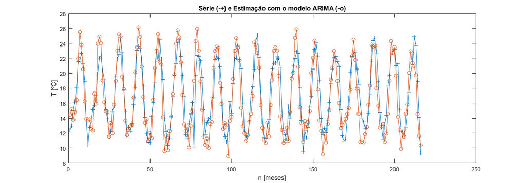

```matlab
%--- Ex. 3.8
% Estimação do modelo ARIMA

serie_treino=x1ro(1:iDez00);
serie_teste=x1ro(iDez00+1:end);
EstMd1 = estimate(Md1,serie_treino);

% Simulação do modelo ARIMA
y1_ARIMA = simulate(EstMd1,numel(serie_teste),...
    'Y0',serie_treino(end-(p1_ARIMA+D1_ARIMA)+1:end));
figure % Compara a série com a sua estimação
plot(to,serie_teste,'-+',to,y1_ARIMA,'-o');
ylabel('T [ºC]')
xlabel('n [meses]');
title('Série (-+) e Estimação com o modelo ARIMA (-o)')

% Métrica para análise
E1_ARIMA=sum(((serie_teste)-(y1_ARIMA)).^2)
```